# Lab 1

Kolton Knight

2025-01-24

Read in data from CSV file, then view, finally attach as default object.

```r
EPI_data <- read.csv('C:/Users/kolto/Documents/Data Analytics/epi2024results06022024.csv')
View(EPI_data)
attach(EPI_data)
```

Check and Filter NA

```r
NAs <- is.na(EPI.new)
EPI.new.noNAs <- EPI.new[!NAs]
```

Summary Stats 2 ways

```r
summary(EPI.new)
```

```
##    Min. 1st Qu.  Median    Mean 3rd Qu.    Max.
##   24.50   38.25   45.50   46.84   53.10   75.30
```

```r
fivenum(EPI.new, na.rm=TRUE)
```

```
## [1] 24.5 38.2 45.5 53.1 75.3
```

Stem and Leaf Plot

```r
stem(EPI.new)
```

```
##
##   The decimal point is 1 digit(s) to the right of the |
##
##   2 |
##   2 | 5667889
##   3 | 001122233334444
##   3 | 5555666666777777788888889999999
##   4 | 0000000111122222222333333334444
##   4 | 5555556666667777777778888889999999
##   5 | 000011122222233333444
##   5 | 5666677788
##   6 | 0011223334444
##   6 | 56677777889
##   7 | 0134
##   7 | 555
```

Histogram with sequence specified (Min, Max, Step), Prob = true plots probability densities so total area = 1

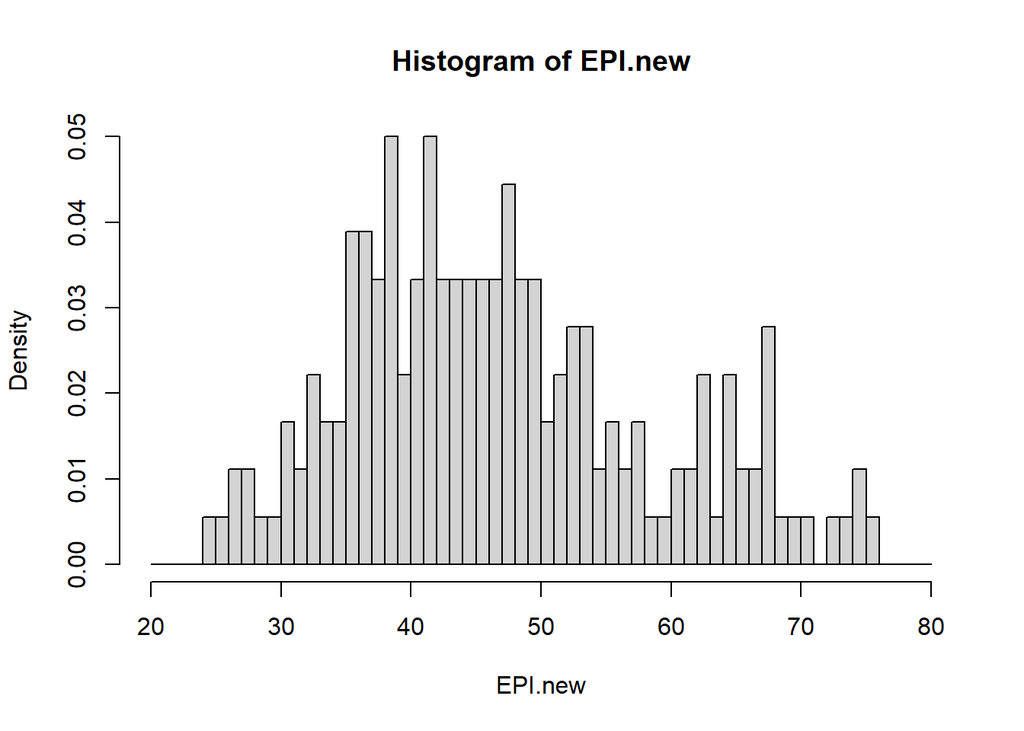

```r
hist(EPI.new, seq(20., 80., 1.0), prob=TRUE)
```

Histogram with Lines Drawn *Gotta run everything together

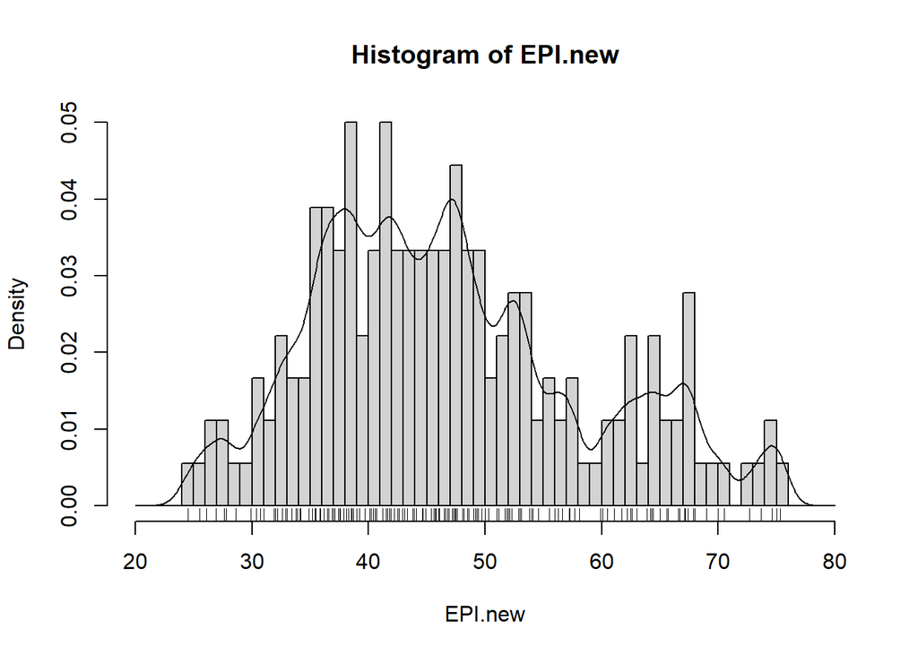

```r
hist(EPI.new, seq(20., 80., 1.0), prob=TRUE)
lines(density(EPI.new, na.rm=TRUE, bw=1.))
rug(EPI.new)
```

Histogram with smoother line

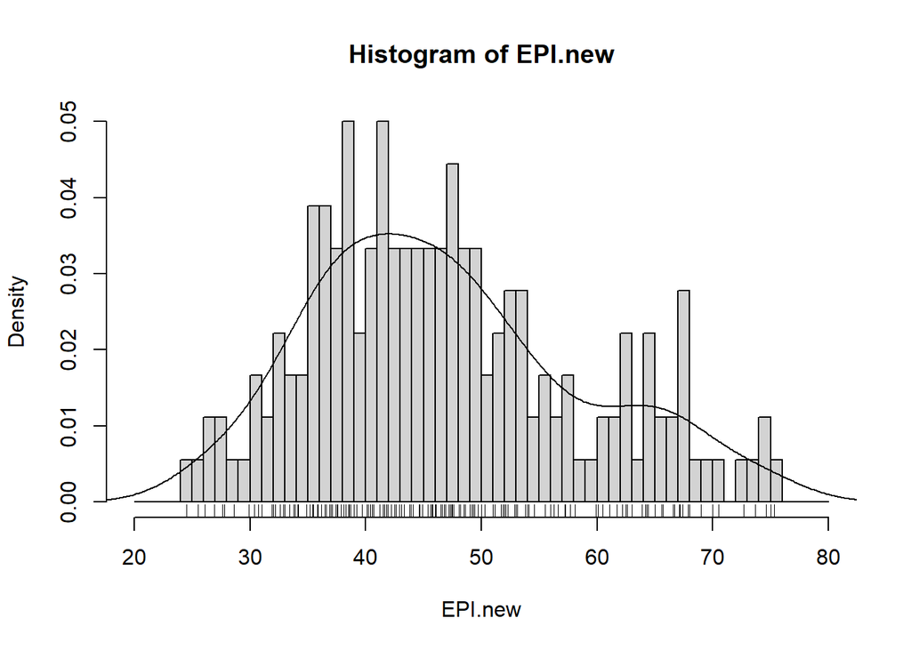

```r
hist(EPI.new, seq(20., 80., 1.0), prob=TRUE)
lines(density(EPI.new, na.rm=TRUE, bw="SJ"))
rug(EPI.new)
```

Fitting two normal distributions in histogram w smooth line

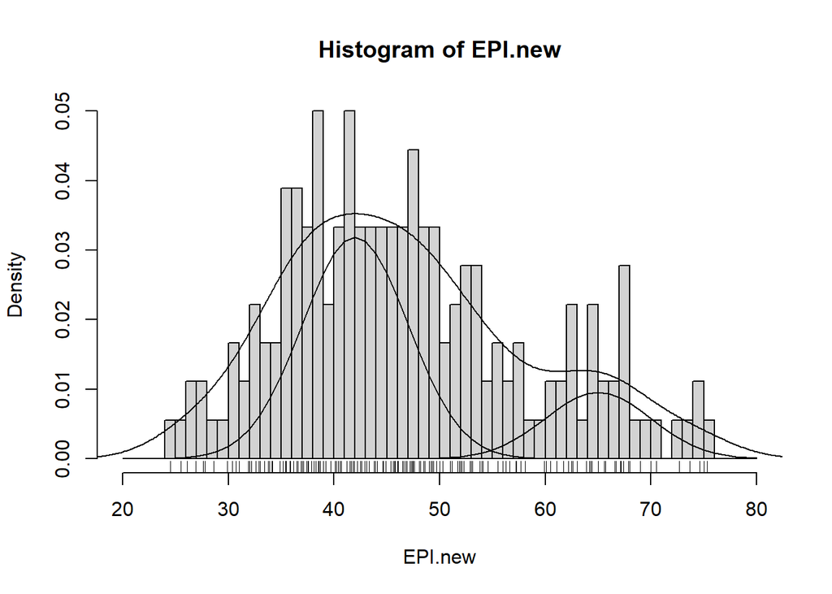

```r
hist(EPI.new, seq(20., 80., 1.0), prob=TRUE)
lines(density(EPI.new, na.rm=TRUE, bw="SJ"))
rug(EPI.new)
x<-seq(20,80,1)
q<- dnorm(x,mean=42, sd=5,log=FALSE)
#lines(x,q)
lines(x,.4*q)
q<-dnorm(x,mean=65, sd=5,log=FALSE)
lines(x,.12*q)
```

Cumulative Density Function

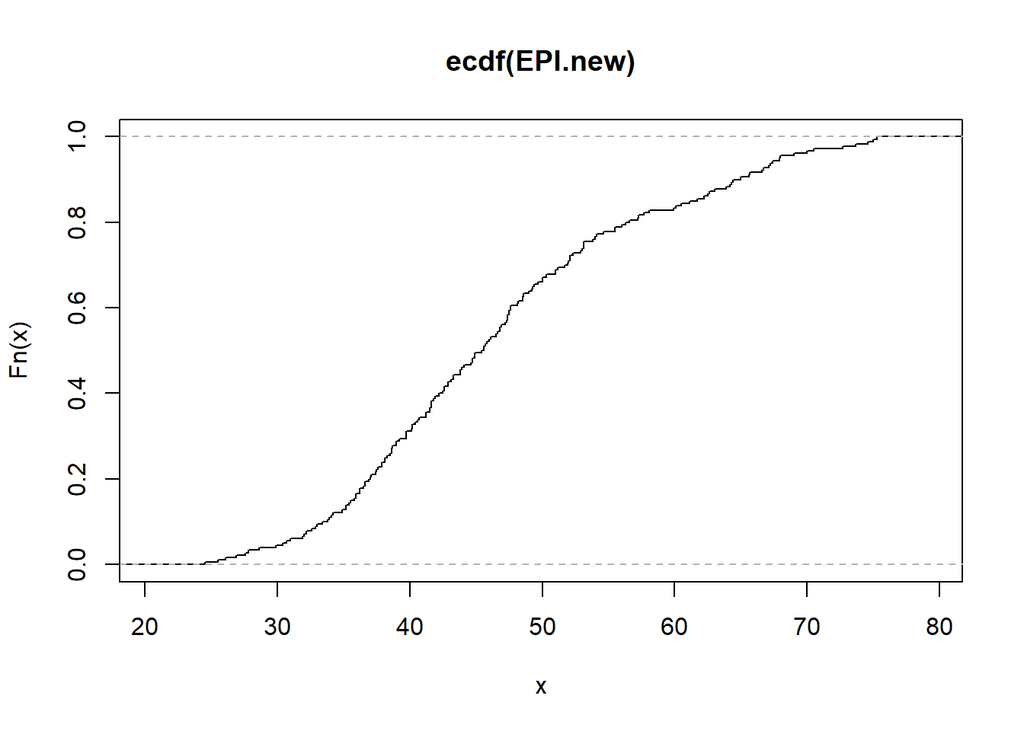

```r
plot(ecdf(EPI.new), do.points=FALSE, verticals=TRUE)
```

Quantile-Quantile

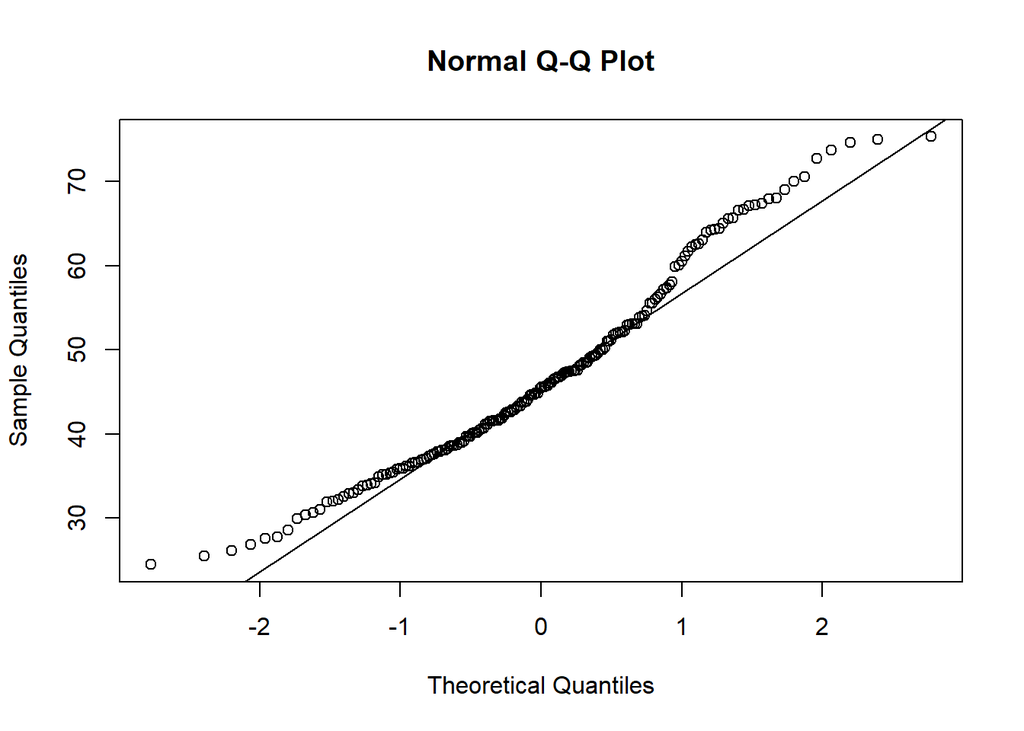

```r
qqnorm(EPI.new)
qqline(EPI.new)
```

Q-Q plot for normal distribution

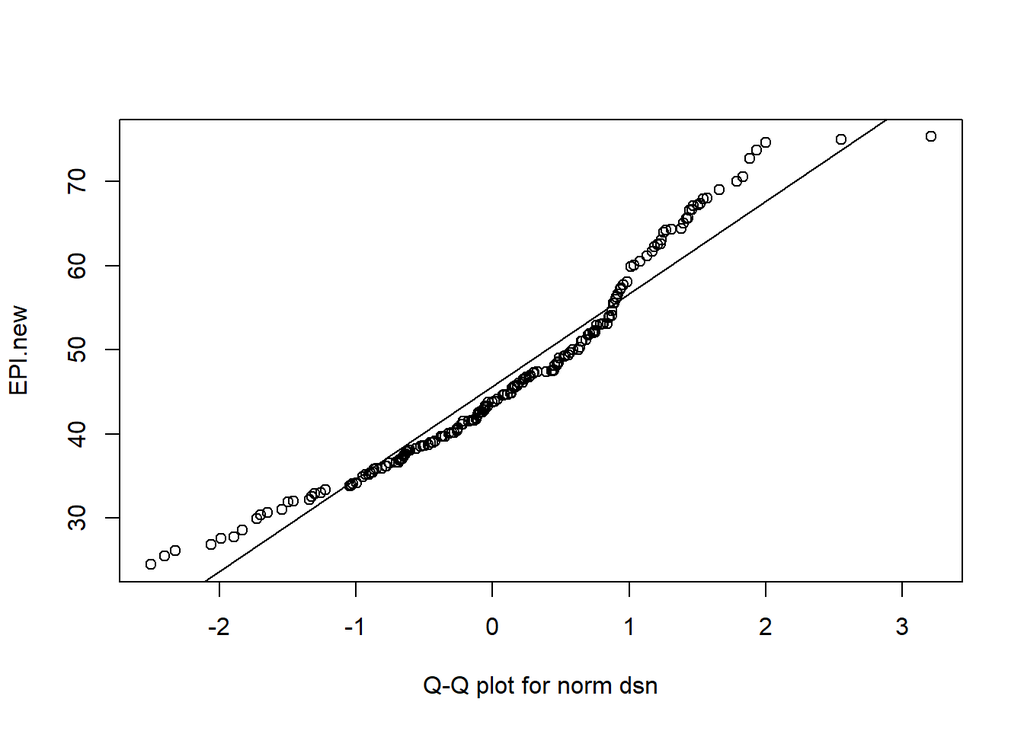

```r
qqplot(rnorm(250), EPI.new, xlab = "Q-Q plot for norm dsn")
qqline(EPI.new)
```

Q-Q plot for t distribution

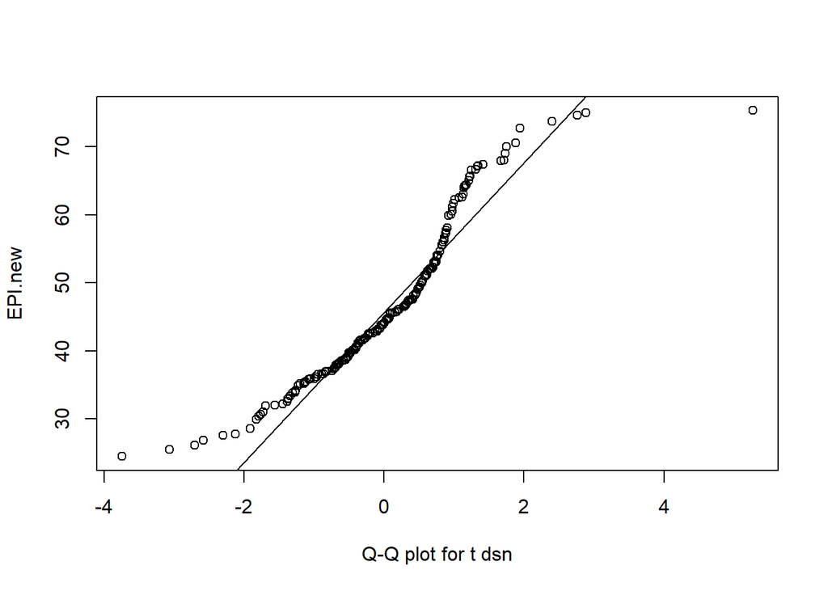

```r
qqplot(rt(250, df = 5), EPI.new, xlab = "Q-Q plot for t dsn")
qqline(EPI.new)
```

Summary Stats 2 ways - SPI.new

```r
summary(SPI.new)
```

```
##    Min. 1st Qu.  Median    Mean 3rd Qu.    Max.    NA's
##    0.00   26.88   51.60   49.84   71.95  100.00       2
```

```r
fivenum(SPI.new, na.rm=TRUE)
```

```
## [1]   0.0  26.4  51.6  72.0 100.0
```

Check and Filter NA

```r
NAs <- is.na(SPI.new)
SPI.new.noNAs <- SPI.new[!NAs]
```

Stem and Leaf Plot - SPI.new

```r
stem(SPI.new.noNAs)
```

```
##
##   The decimal point is 1 digit(s) to the right of the |
##
##    0 | 00011113444445788889
##    1 | 1344455788999
##    2 | 001122355566889
##    3 | 1122333444555677777789999
##    4 | 0122333356779
##    5 | 00123444567778888899
##    6 | 0233355566788889999
##    7 | 0000122222334556788999
##    8 | 1123344455579
##    9 | 00011124445666789
##   10 | 0
```

Histogram with Lines Drawn - SPI.new

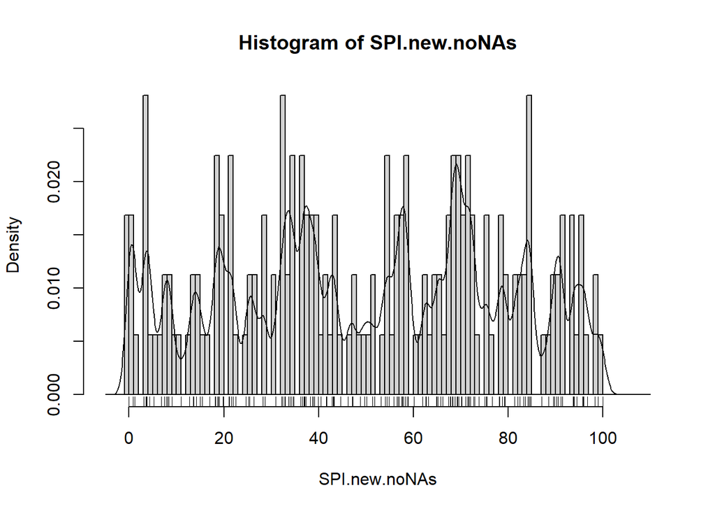

```r
hist(SPI.new.noNAs, seq(-5., 110., 1.0), prob=TRUE)
lines(density(SPI.new.noNAs, na.rm=TRUE, bw=1.))
rug(SPI.new.noNAs)
```

Histogram with Smooth Lines Drawn - SPI.new

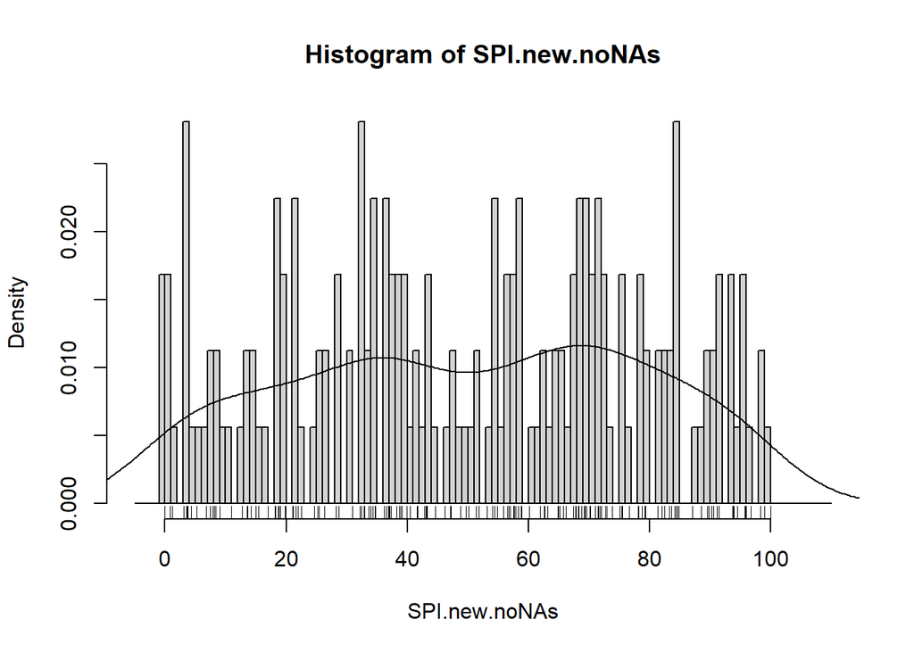

```r
hist(SPI.new.noNAs, seq(-5., 110., 1.0), prob=TRUE)
lines(density(SPI.new.noNAs, na.rm=TRUE, bw='SJ'))
rug(SPI.new.noNAs)
```

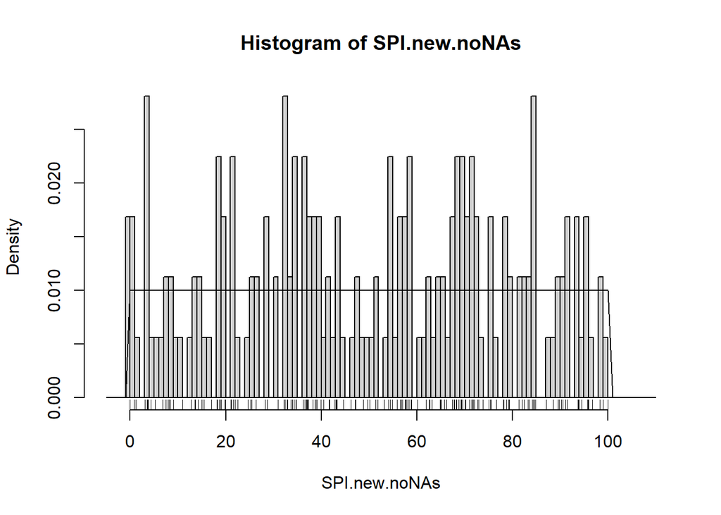

```r
hist(SPI.new.noNAs, seq(-5., 110., 1.0), prob=TRUE)
#lines(density(SPI.new.noNAs, na.rm=TRUE, bw="SJ"))
rug(SPI.new.noNAs)
x<-seq(-5., 110., 1.0)
q<- dunif(x,min = 0, max = 100, log=FALSE)
lines(x,q)
```

Comparing EPI.new and SPI.new

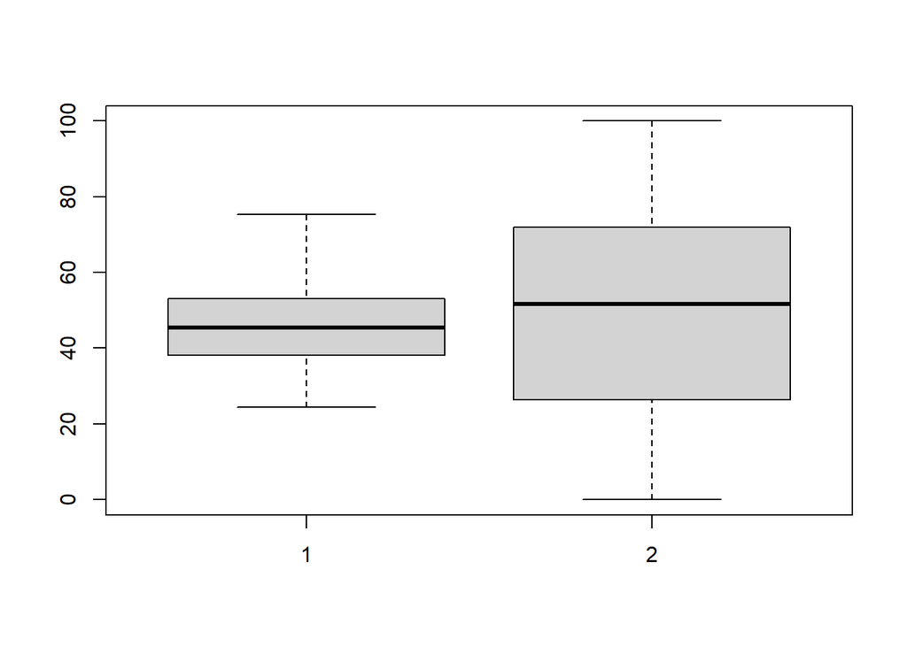

```r
boxplot(EPI.new, SPI.new.noNAs)
```

Cumulative Density Function - SPI

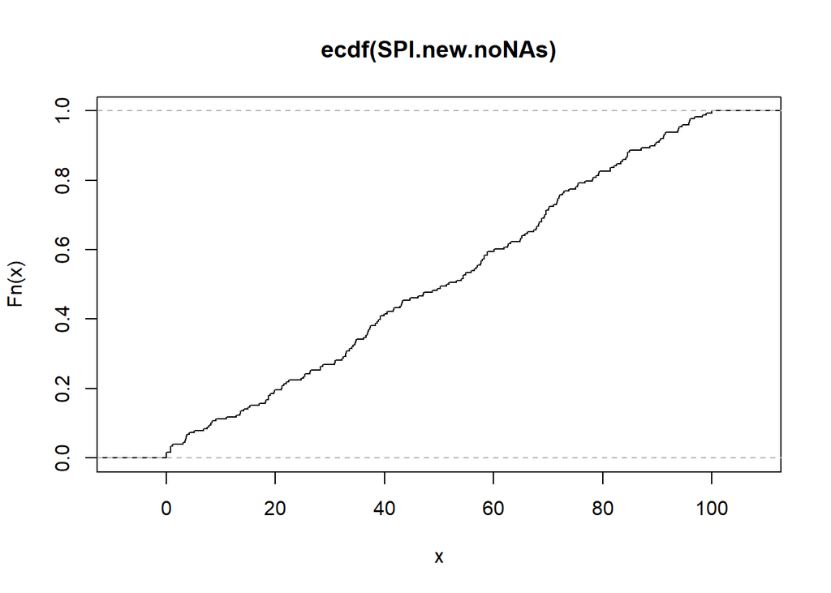

```r
plot(ecdf(SPI.new.noNAs), do.points=FALSE, verticals=TRUE)
```

Quantile-Quantile - SPi

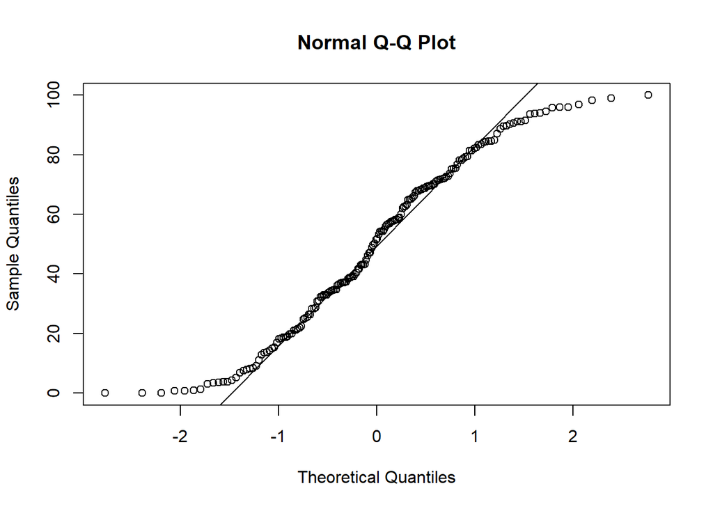

```r
qqnorm(SPI.new.noNAs)
qqline(SPI.new.noNAs)
```

Q-Q plot for normal distribution - SPi

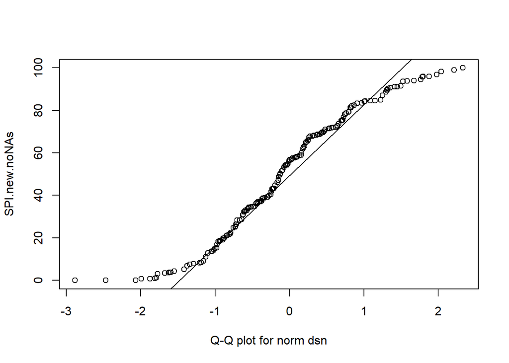

```r
qqplot(rnorm(250), SPI.new.noNAs, xlab = "Q-Q plot for norm dsn")
qqline(SPI.new.noNAs)
```

Q-Q plot for t distribution - SPi

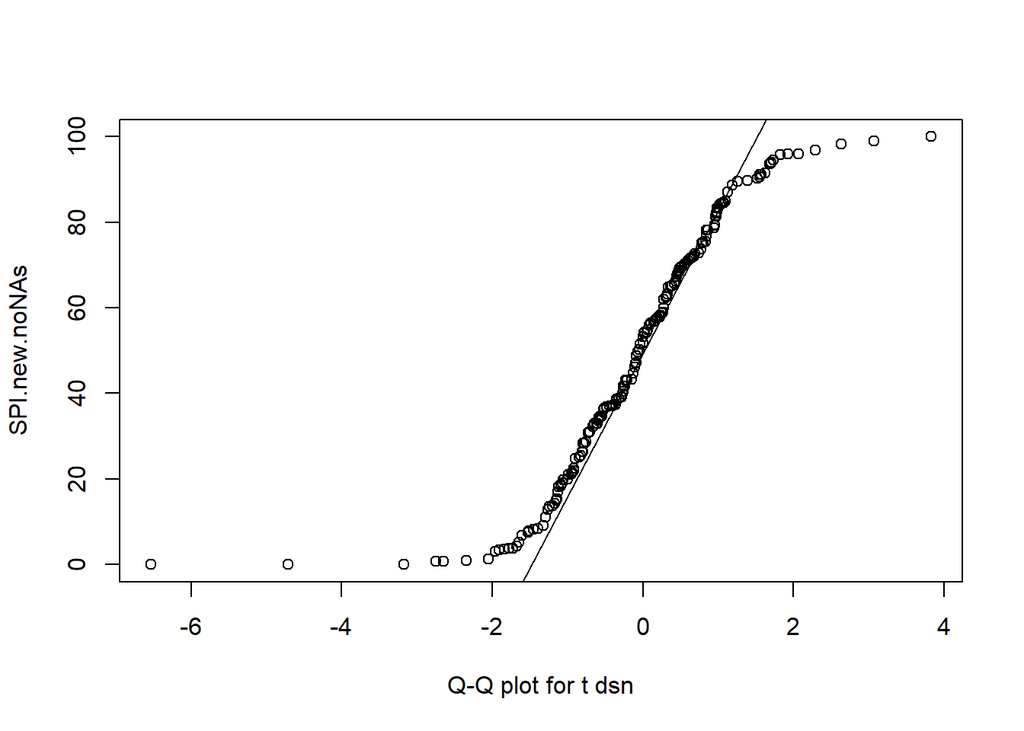

```r
qqplot(rt(250, df = 5), SPI.new.noNAs, xlab = "Q-Q plot for t dsn")
qqline(SPI.new.noNAs)
```

Summary Stats 2 ways - TBN.new

```r
summary(TBN.new)
```

```
##    Min. 1st Qu.  Median    Mean 3rd Qu.    Max.
##    0.00   27.88   53.25   52.04   76.62  100.00
```

```r
fivenum(TBN.new, na.rm=TRUE)
```

```
## [1]   0.00  27.85  53.25  76.65 100.00
```

```r
sd(TBN.new, na.rm=TRUE)
```

```
## [1] 30.26794
```

Check and Filter NA

```r
NAs <- is.na(TBN.new)
TBN.new.noNAs <- TBN.new[!NAs]
```

Comparing EPI.new and TBN.new

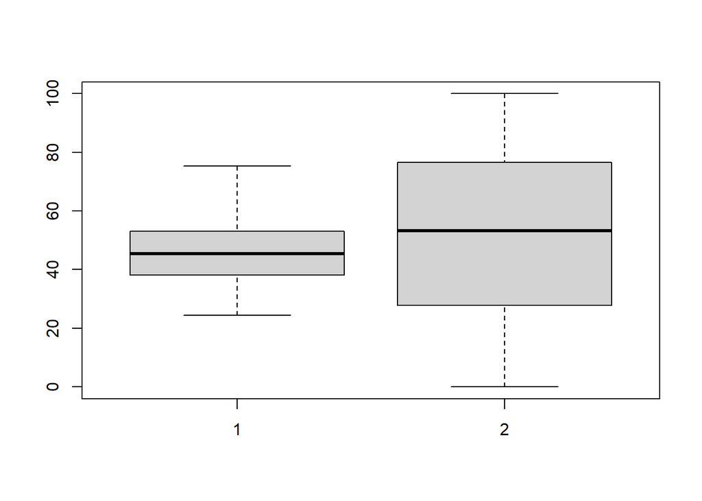

```r
boxplot(EPI.new, TBN.new.noNAs)
```

Histogram with Lines Drawn - TBN.new

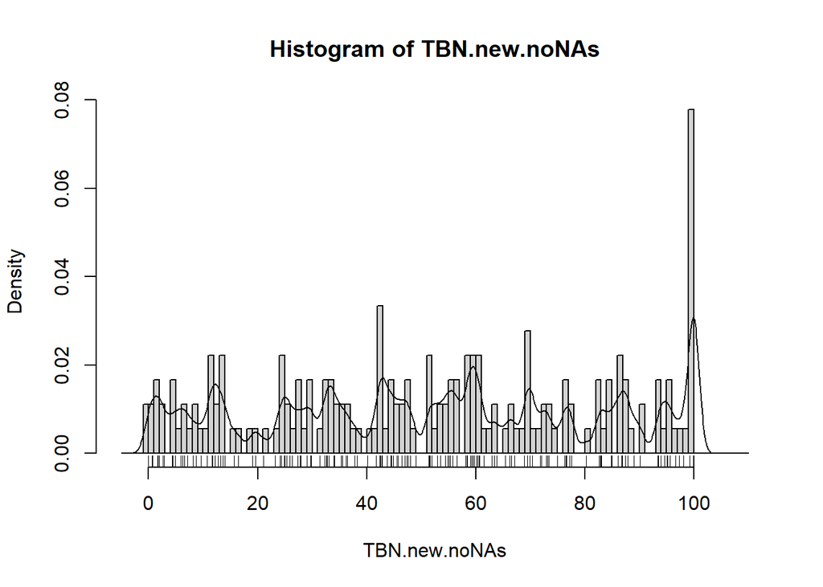

```r
hist(TBN.new.noNAs, seq(-5., 110., 1.0), prob=TRUE)
lines(density(TBN.new.noNAs, na.rm=TRUE, bw=1.))
rug(TBN.new.noNAs)
```

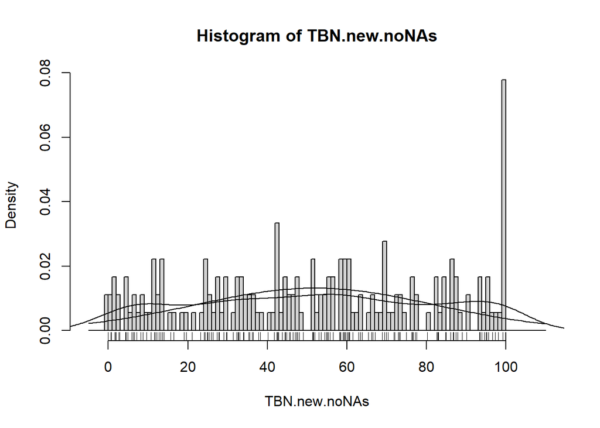

```r
hist(TBN.new.noNAs, seq(-5., 110., 1.0), prob=TRUE)
lines(density(TBN.new.noNAs, na.rm=TRUE, bw="SJ"))
rug(TBN.new.noNAs)
x<-seq(-5., 110., 1.0)
q<- dnorm(x, mean = 52, sd = 30.2679, log=FALSE)
lines(x,q)
```

Cumulative Density Function - TBN.new

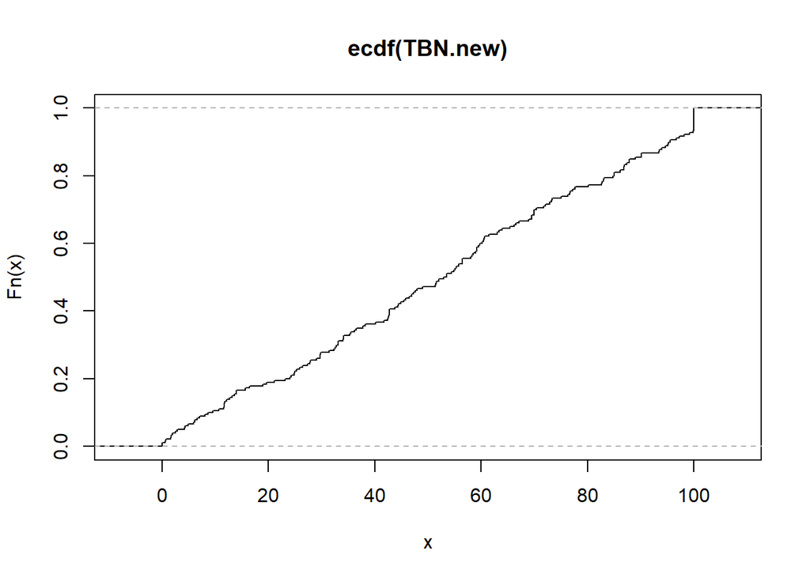

```r
plot(ecdf(TBN.new), do.points=FALSE, verticals=TRUE)
```

Quantile-Quantile - TBN.new

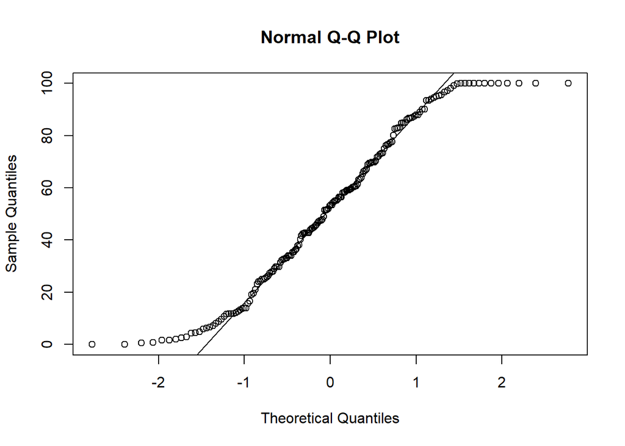

```r
qqnorm(TBN.new)
qqline(TBN.new)
```

Q-Q plot for normal distribution - TBN.new

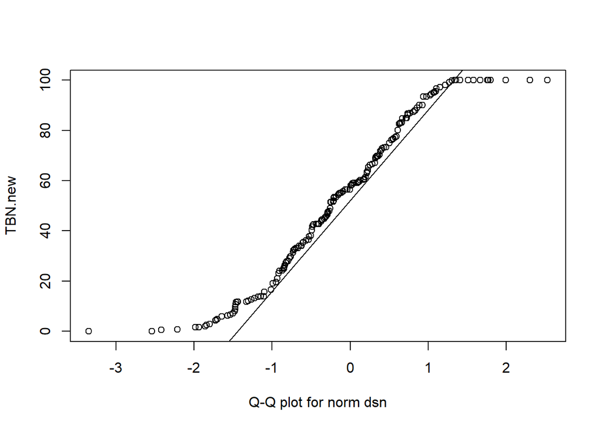

```r
qqplot(rnorm(250), TBN.new, xlab = "Q-Q plot for norm dsn")
qqline(TBN.new)
```

Q-Q plot for t distribution - TBN.new

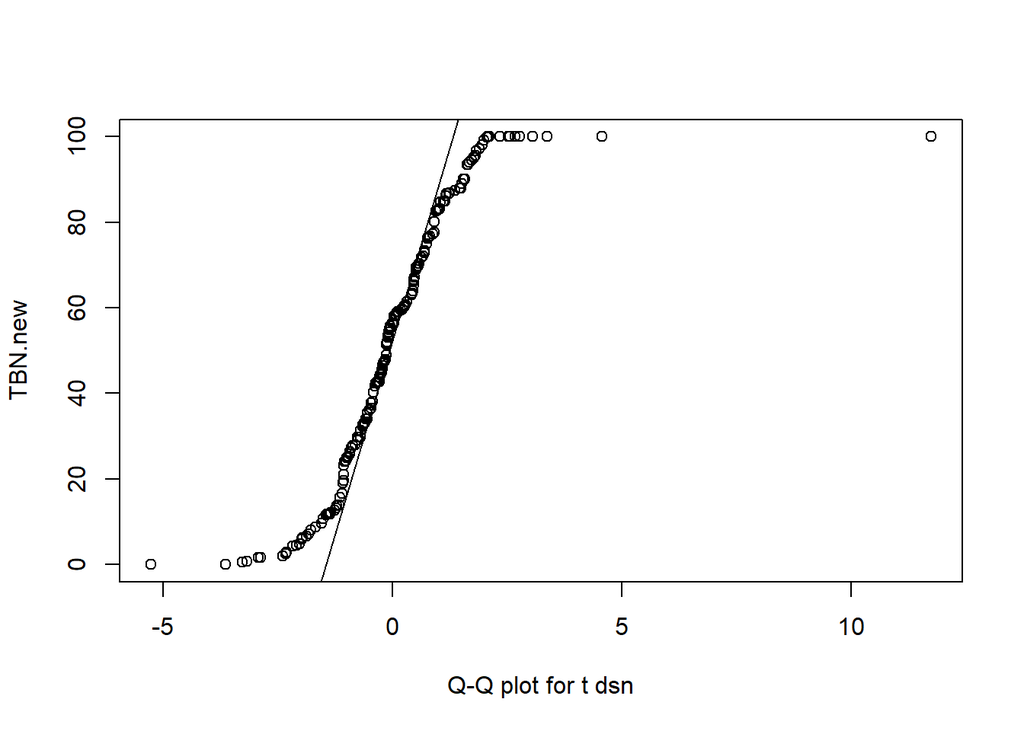

```r
qqplot(rt(250, df = 5), TBN.new, xlab = "Q-Q plot for t dsn")
qqline(TBN.new)
```